# Microbial growth

introduction to microbial growth using Monod’s equation

### Monod equation

Sometimes, microbial population growth in a limited nutrient environment is modeled with Monod’s equation. It describes the relationship between the specific growth rate of the microorganism and the concentration of a limiting nutrient in the environment. Monod’s equation assumes that growth rate increases as the concentration of the limiting nutrient increases until it reaches a maximum growth rate (maximum specific growth rate). Beyond this point, the growth rate becomes constant even if the nutrient concentration continues to increase.

#### Learning Objectives:

1. Understand Monod’s equation and its application in describing microbial growth.
2. Learn about the parameters of Monod’s equation and their significance.
3. Visualize the relationship between growth rate and substrate concentration using ggplot2.

The Monod model assumes growth is balanced, there is no inhibition caused by metabolism products, and the organisms are planktonic in Newtonian fluids that are not very viscous.

*Typically, microbial growth consists of a lag phase, a log phase, a stationary phase, and a death or decline phase.*

```r
# Define Monod's equation
monod <- function(S, mu_max, Ks) {
  mu <- mu_max * (S / (Ks + S))
  return(mu)
}
```

Generate substrate concentrations

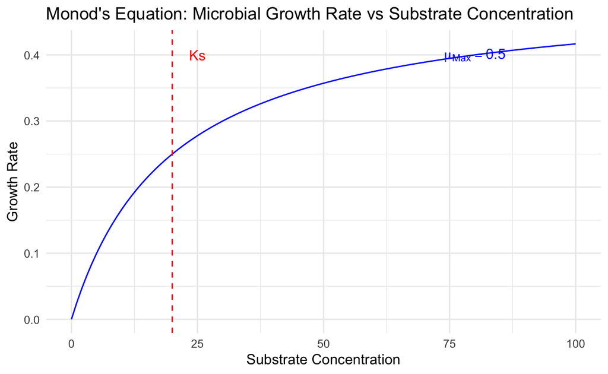

```r
S <- seq(0, 100, by = 1) # Substrate concentration range

# Set parameter values
mu_max <- 0.5  # Maximum specific growth rate (per time unit)
Ks <- 20       # Half-saturation constant (substrate concentration at half the maximum growth rate)

# Calculate growth rates using Monod's equation
growth_rate <- monod(S, mu_max, Ks)

# Create dataframe for plotting
monod_data <- data.frame(S = S, Growth_Rate = growth_rate)

# Plot Monod curve
ggplot(data = monod_data, aes(x = S, y = Growth_Rate)) +
  geom_line(color = "blue") +
  labs(x = "Substrate Concentration", y = "Growth Rate",
       title = "Monod's Equation: Microbial Growth Rate vs Substrate Concentration") +
  theme_minimal() +
  geom_vline(xintercept = Ks, linetype = "dashed", color = "red") +
  annotate("text", x = Ks + 5, y = 0.4, label = "Ks", color = "red") +
  annotate("text", x = 80, y = 0.4, label = expression(mu[Max] == 0.5), color = "blue")
```

The Monod model consists of a few parameters.
$$µ = µ_{max} × {S}/{(K_s + S)}$$
$µ$ Represents the specific growth rate of the microorganisms

The maximum specific growth rate ($µ_{max}$) represents the intrinsic growth potential of the microorganism under optimal conditions.

The half-saturation constant ($K_s$) is the substrate concentration at which the specific growth rate is half of the maximum. It indicates the affinity of the microorganism for the substrate.

The substrate concentration ($S$) affects the specific growth rate according to the Michaelis-Menten kinetics.

In this first model, we will assume substrate concentration is constant $S_0$

It is also possible for two different nutrients limiting growth such as Carbon, Nitrogen, or others.

$$µ = µ_{max} × {S_1}/{(K_{s1} + S_1)} × {S_2}/{(K_{s2} + S_1)}$$

#### Reflective Questions:

- What does Monod’s equation describe, and what are its main assumptions?
- How do changes in the parameter values affect the shape of the Monod curve?
- Can you identify situations in real-world environments where Monod’s equation might be applicable?
- How might deviations from Monod’s equation occur in complex microbial communities?
- How does the shape of the Monod curve change with different parameter values of mu_max and Ks?
- What does the half-saturation constant (Ks) represent in Monod’s equation, and why is it important in microbial growth kinetics?
- Can you think of examples where Monod’s equation might not accurately describe microbial growth dynamics? What factors could influence deviations from Monod kinetics?